# Spatial Exploration of Colorado

The Census has made a great deal of information available about both Colorado and Massachussetts which we can access via the Census API. Only a subset of the available Census data (described [here](http://www.census.gov/developers/data/) is accessible in this manner. However, we can get at the [Summary File 1](http://www.census.gov/2010census/news/press-kits/summary-file-1.html) data for 1990, 2000, and 2010. [Summary File 3](http://www.census.gov/census2000/sumfile3.html) information (detailed social, economic, and housing information) is available for 1990 and 2000, but much of this function was farmed out to the [American Community Survey](http://www.census.gov/acs/www/) by the time of the 2010 Census.

As with CO_muni_county, this will serve to help identify what we should focus on in Massachusetts.

## Plotting Census Tracts

Probably the best combination of relative granularity and detailed information occurs at the census tract level, so we will start there.

```python
from IPython.display import HTML

#Enable R capability
%load_ext rmagic
```

We need some metadata, and other information wouldn't hurt either, so here is the documentation on Census shapefiles:

```python
HTML('<iframe src=http://www.census.gov/geo/maps-data/data/pdfs/tiger/tgrshp2012/TGRSHP2012_TechDoc.pdf width=1000 height=550></iframe>')
```

[interactive chart not shown]

```python
%%R
library(maptools)
library(gpclib)
library(sp)
library(ggmap)
library(rgdal)
library(raster)

#Read in Ward shapefile
c<-readShapeSpatial('/home/choct155/Google Drive/Dissertation/Data/spatial/CO/tl_2012_08_tract.shp')
projection(c) <- '+proj=longlat +datum=NAD83'
print(summary(c))
cat('\n')
print(head(c))
cat('\n')

#Convert to WGS84
co_ll<-spTransform(c,CRS('+proj=longlat +datum=WGS84'))

#Convert to R df
co<-fortify(co_ll)

print(summary(co))
```

```
Checking rgeos availability: TRUE
General Polygon Clipper Library for R (version 1.5-5)
	Type 'class ? gpc.poly' for help
rgdal: version: 0.8-10, (SVN revision 478)
Geospatial Data Abstraction Library extensions to R successfully loaded
Loaded GDAL runtime: GDAL 1.9.0, released 2011/12/29
Path to GDAL shared files: /usr/share/gdal/1.9
Loaded PROJ.4 runtime: Rel. 4.7.1, 23 September 2009, [PJ_VERSION: 470]
Path to PROJ.4 shared files: (autodetected)
Object of class SpatialPolygonsDataFrame
Coordinates:
         min        max
x -109.06026 -102.04152
y   36.99242   41.00344
Is projected: FALSE
proj4string :
[+proj=longlat +datum=NAD83 +ellps=GRS80 +towgs84=0,0,0]
Data attributes:
 STATEFP      COUNTYFP      TRACTCE             GEOID           NAME
 08:1249   005    :147   000100 :  14   08001007801:   1   1      :  14
           031    :144   000300 :  12   08001007802:   1   3      :  12
           059    :138   000200 :  11   08001007900:   1   2      :  11
           041    :130   000600 :  10   08001008000:   1   6      :  10
           001    : 97   000500 :   9   08001008100:   1   5      :   9
           123    : 77   000400 :   8   08001008200:   1   4      :   8
           (Other):516   (Other):1185   (Other)    :1243   (Other):1185
           NAMELSAD      MTFCC      FUNCSTAT     ALAND
 Census Tract 1:  14   G5020:1249   S:1249   Min.   :1.053e+05
 Census Tract 3:  12                         1st Qu.:1.932e+06
 Census Tract 2:  11                         Median :3.554e+06
 Census Tract 6:  10                         Mean   :2.149e+08
 Census Tract 5:   9                         3rd Qu.:2.250e+07
 Census Tract 4:   8                         Max.   :1.187e+10
 (Other)       :1185
     AWATER                INTPTLAT            INTPTLON
 Min.   :       0   +37.0735116:   1   -102.1449177:   1
 1st Qu.:       0   +37.1012414:   1   -102.2113995:   1
 Median :    5539   +37.1016255:   1   -102.2201088:   1
 Mean   :  937171   +37.1079253:   1   -102.2561784:   1
 3rd Qu.:  171038   +37.1226214:   1   -102.2951766:   1
```

[output cut: 19 more lines]

```
 Min.   :-109.1   Min.   :36.99   Min.   :   1   Mode :logical   1:740146
 1st Qu.:-107.0   1st Qu.:38.45   1st Qu.: 190   FALSE:740918    2:  7213
 Median :-105.3   Median :39.31   Median : 700   TRUE :7433      3:   941
 Mean   :-105.8   Mean   :39.13   Mean   :1151   NA's :0         4:    51
 3rd Qu.:-104.9   3rd Qu.:39.80   3rd Qu.:1715
 Max.   :-102.0   Max.   :41.00   Max.   :8513

     group             id
 812.1  :  8513   Length:748351
 462.1  :  7304   Class :character
 709.1  :  7204   Mode  :character
 706.1  :  6378
 946.1  :  5247
 704.1  :  5080
 (Other):708625
```

Shapefile loaded, let's see if we can actually plot that piece before going through the trouble of data management.

```
Google Maps API Terms of Service : http://developers.google.com/maps/terms
Google Maps API Terms of Service : http://developers.google.com/maps/terms
```

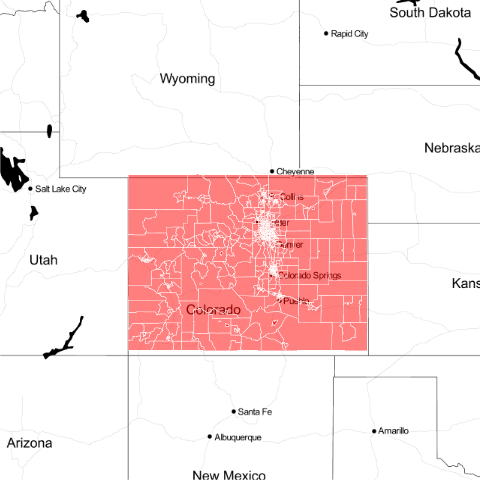

```python
%%R
#Create base map
comap<-qmap('colorado',zoom=6,maptype='toner',source='stamen')

#Combine ward data with base map
print(comap + geom_polygon(aes(x=long,y=lat,group=group),
                           data=co,colour='white',fill='red',alpha=.5,size=.2))
```

Not a perfect fit, but close enough for the time being since I am more interested in plotting the data. Incidentally, what happens if I ignore the base map?

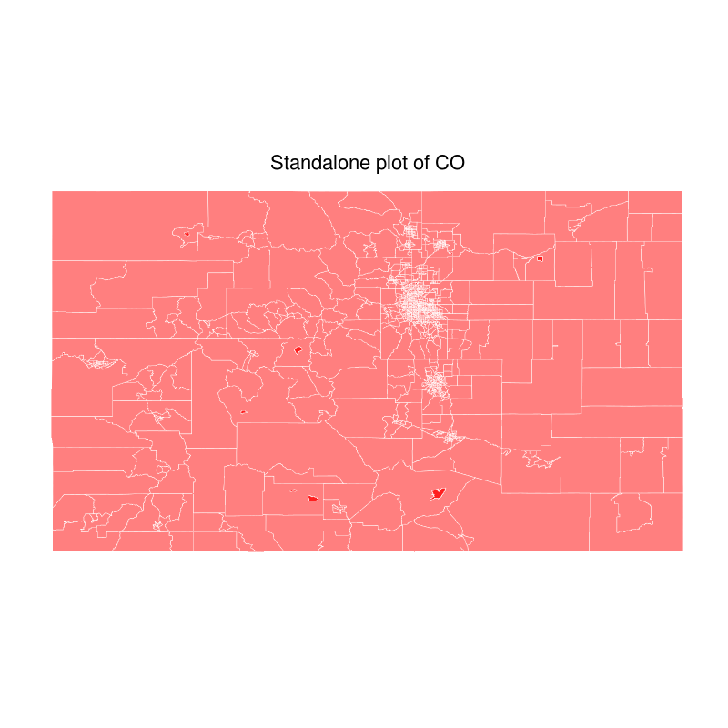

```python
%%R -w 800 -h 800

#Blank theme
theme_opts <- list(theme(panel.grid.minor = element_blank(),
                        panel.grid.major = element_blank(),
                        panel.background = element_blank(),
                        plot.background = element_blank(),
                        panel.border = element_blank(),
                        axis.line = element_blank(),
                        axis.text.x = element_blank(),
                        axis.text.y = element_blank(),
                        axis.ticks = element_blank(),
                        axis.title.x = element_blank(),
                        axis.title.y = element_blank(),
                        plot.title = element_text(size=22)))


print(ggplot(aes(x=long,y=lat,group=group),data=co) + geom_polygon(colour='white',fill='red',alpha=.5,size=.2) +
     coord_equal() + theme_opts + labs(title='Standalone plot of CO'))
```

Hmmm, apparently I can do that just fine. I got rid of the background elements that typicaly accompany ggplots with the theme.

## Acquiring Census Data

Moving on, let's couple some data with the fortified shapefile. To grab the data, we will be using the Census API. Here is my key: b62798704de5e04d638987171ec291a6889c16bf

We are going to utilize a quick wrapper to pull this data more efficiently.

**Note**: To use the *pandas.read_json()* method below, you must be using pandas-0.12+

```python
import numpy as np
import pandas as pd
from pandas import Series,DataFrame
import urllib2

def census(year,product,indicator,geo,location,prnt=False):
    #Establish request string
    req='http://api.census.gov/data/'+year+'/'+product+'?key=b62798704de5e04d638987171ec291a6889c16bf&get='+indicator+',NAME&for='+geo+'&in='+location

    #Print option
    if prnt:
        print req
    else:
        pass
    #Open connection to Census API
    request = urllib2.urlopen(req)

    #Read data as json and use convert to dataframe
    req = pd.read_json(request.read())

    #First row of 'data' values are really column headings, so subset to real data
    req_df=DataFrame(req[1:])

    #Use that first row to set column labels
    req_df.columns=list(req[:1].values)
    return req_df

HTML(census('2010','sf1','P0010001','tract:*','state:08+county:001')[:20].to_html())
```

|  | P0010001 | NAME | state | county | tract |
| --- | --- | --- | --- | --- | --- |
| 1 | 3732 | Census Tract 78.01 | 08 | 001 | 007801 |
| 2 | 3758 | Census Tract 78.02 | 08 | 001 | 007802 |
| 3 | 5555 | Census Tract 79 | 08 | 001 | 007900 |
| 4 | 5742 | Census Tract 80 | 08 | 001 | 008000 |
| 5 | 854 | Census Tract 81 | 08 | 001 | 008100 |
| 6 | 5484 | Census Tract 82 | 08 | 001 | 008200 |
| 7 | 5557 | Census Tract 83.08 | 08 | 001 | 008308 |
| 8 | 3254 | Census Tract 83.09 | 08 | 001 | 008309 |
| 9 | 6044 | Census Tract 83.53 | 08 | 001 | 008353 |
| 10 | 4315 | Census Tract 84.01 | 08 | 001 | 008401 |
| 11 | 4352 | Census Tract 84.02 | 08 | 001 | 008402 |
| 12 | 6655 | Census Tract 85.05 | 08 | 001 | 008505 |
| 13 | 5383 | Census Tract 85.06 | 08 | 001 | 008506 |
| 14 | 6099 | Census Tract 85.07 | 08 | 001 | 008507 |
| 15 | 5342 | Census Tract 85.08 | 08 | 001 | 008508 |
| 16 | 7586 | Census Tract 85.23 | 08 | 001 | 008523 |
| 17 | 7814 | Census Tract 85.24 | 08 | 001 | 008524 |
| 18 | 6742 | Census Tract 85.26 | 08 | 001 | 008526 |
| 19 | 7446 | Census Tract 85.29 | 08 | 001 | 008529 |
| 20 | 7650 | Census Tract 85.33 | 08 | 001 | 008533 |

So, we have discovered something interesting in experimenting with the requests above. I initially tried to pull all of the tract data in Colorado, which seemed reasonable. When it didn't work, I beat my head on the desk for a while trying to understand what was wrong with my syntax. As pointed out by a helpful [post](http://apiforum.ideascale.com/a/dtd/wildcarding-geo-values/168057-18378) on the [Census Developer Forum](http://apiforum.ideascale.com/), when you run a portal to such large data sources, you have to be careful about worst case loads. For this reason, there are request configurations that are restricted. The worst case scenario is a request like the following:

```
[...]get=P0010001&for=block:*&in=state:*+county:*+tract:*
```

Pulling all blocks in all states, counties, and tracts is a request that is 11 million records deep. Imagine many people doing this within a given time window, and it's a recipe for disaster. For that reason, smaller requests are enforced via allowable parameter combinations. I imagine there is also a limit on the number of requests that can be made per day, because one could just wrap these requests in loop structures (like we are going to do). Ultimately, this may end up limiting the usefulness of the API for comprehensive analysis, but we might as well find out.

Let's see if we can pull the population for all tracts in Colorado. First, we need to know how many counties we have.

Tags and examples for each geography level can be found in these locations: >1. SF1: [2010](http://api.census.gov/data/2010/sf1/geo.html), [2000](http://api.census.gov/data/2000/sf1/geo.html), [1990](http://api.census.gov/data/1990/sf1/geo.html)

> 2. ACS 5-yr: [2007-2011](http://api.census.gov/data/2011/acs5/geo.html), [2006-2010](http://api.census.gov/data/2010/acs5/geo.html)

```python
#Grab data
co_cty_pop=census('2010','sf1','P0010001','county:*','state:08')

#Print summary
print co_cty_pop

#Grab list of county IDs
co_cty_id=list(co_cty_pop['county'].values)

#Grab list of county names and create a dictionary for mapping a new variable
co_cty_name=list(co_cty_pop['NAME'].values)
cty_name_dict=dict(zip(co_cty_id,co_cty_name))

#Look at first 10 records for confirmation
HTML(co_cty_pop[:10].to_html())
```

```
<class 'pandas.core.frame.DataFrame'>
Int64Index: 64 entries, 1 to 64
Data columns (total 4 columns):
P0010001    64  non-null values
NAME        64  non-null values
state       64  non-null values
county      64  non-null values
dtypes: object(4)
```

|  | P0010001 | NAME | state | county |
| --- | --- | --- | --- | --- |
| 1 | 441603 | Adams County | 08 | 001 |
| 2 | 15445 | Alamosa County | 08 | 003 |
| 3 | 572003 | Arapahoe County | 08 | 005 |
| 4 | 12084 | Archuleta County | 08 | 007 |
| 5 | 3788 | Baca County | 08 | 009 |
| 6 | 6499 | Bent County | 08 | 011 |
| 7 | 294567 | Boulder County | 08 | 013 |
| 8 | 55889 | Broomfield County | 08 | 014 |
| 9 | 17809 | Chaffee County | 08 | 015 |
| 10 | 1836 | Cheyenne County | 08 | 017 |

With all county numerical identifiers in place, we can grab tracts by county and throw them into one large data set.

```python
def subcty(cty_list,year,product,indicator,geo,location,cty_name):
    #Generate container for county level data sets
    cty_data=[]

    #For each county ...
    for cty in cty_list:
        #Create a new, composite location parameter
        loc_cty=location+'+county:'+cty

        #Use inputs from warapper function and substitute location
        data=census(year,product,indicator,geo,loc_cty)

        #Throw county level result in container
        cty_data.append(data)

    #Concatenate into one set after all county data is read in
    all_cty=pd.concat(cty_data)

    #Include count names
    all_cty['cty_name']=all_cty['county'].map(cty_name)

    return all_cty

co_tract_pop=subcty(co_cty_id,'2010','sf1','P0010001','tract:*','state:08',cty_name_dict)
print co_tract_pop
HTML(co_tract_pop[:10].to_html())
```

```
<class 'pandas.core.frame.DataFrame'>
Int64Index: 1249 entries, 1 to 2
Data columns (total 6 columns):
P0010001    1249  non-null values
NAME        1249  non-null values
state       1249  non-null values
county      1249  non-null values
tract       1249  non-null values
cty_name    1249  non-null values
dtypes: object(6)
```

|  | P0010001 | NAME | state | county | tract | cty_name |
| --- | --- | --- | --- | --- | --- | --- |
| 1 | 3732 | Census Tract 78.01 | 08 | 001 | 007801 | Adams County |
| 2 | 3758 | Census Tract 78.02 | 08 | 001 | 007802 | Adams County |
| 3 | 5555 | Census Tract 79 | 08 | 001 | 007900 | Adams County |
| 4 | 5742 | Census Tract 80 | 08 | 001 | 008000 | Adams County |
| 5 | 854 | Census Tract 81 | 08 | 001 | 008100 | Adams County |
| 6 | 5484 | Census Tract 82 | 08 | 001 | 008200 | Adams County |
| 7 | 5557 | Census Tract 83.08 | 08 | 001 | 008308 | Adams County |
| 8 | 3254 | Census Tract 83.09 | 08 | 001 | 008309 | Adams County |
| 9 | 6044 | Census Tract 83.53 | 08 | 001 | 008353 | Adams County |
| 10 | 4315 | Census Tract 84.01 | 08 | 001 | 008401 | Adams County |

Kobe! It would be nice to pull some additional data as well, so we need a codebook. The variables are housed in XML documents, so we will have to parse those to get the mapping. The technique below draws upon my xml_parse Notebook located in this directory:

```
/home/choct155/analysis/utility/
```

We will be opening a socket to access the document in place, and then parsing it to pull information out by the appropriate tags.

```python
from lxml import etree

#Open socket
request=urllib2.urlopen('http://www.census.gov/developers/data/sf1.xml')

#Read in data
census_var=request.read()

#Use XML method to parse file
census_2010var=etree.XML(census_var)

#View concepts available
for element in census_2010var.iter("concept"):
    print("%s - %s" % (element.tag, element.get('name')))
```

```
concept - Geographies
concept - P1. Total Population [1]
concept - P3. RACE [8]
concept - P4. HISPANIC OR LATINO ORIGIN [3]
concept - P5. HISPANIC OR LATINO ORIGIN BY RACE [17]
concept - P6. RACE (TOTAL RACES TALLIED) [7]
concept - P7. HISPANIC OR LATINO ORIGIN BY RACE (TOTAL RACES TALLIED) [15]
concept - P8. RACE [71]
concept - P9. HISPANIC OR LATINO, AND NOT HISPANIC OR LATINO BY RACE [73]
concept - P10. RACE FOR THE POPULATION 18 YEARS AND OVER [71]
concept - P11. HISPANIC OR LATINO, AND NOT HISPANIC OR LATINO BY RACE FOR THE POPULATION 18 YEARS AND OVER [73]
concept - P12. Sex By Age [49]
concept - P18. HOUSEHOLD TYPE [9]
concept - P29. HOUSEHOLD TYPE BY RELATIONSHIP [28]
concept - P39. FAMILY TYPE BY PRESENCE AND AGE OF RELATED CHILDREN [20]
concept - P42. GROUP QUARTERS POPULATION BY GROUP QUARTERS TYPE [10]
concept - P12A. Sex By Age (White Alone) [49]
concept - P12B. Sex By Age (Black Or African American Alone) [49]
concept - P12C. Sex By Age (American Indian And Alaska Native Alone) [49]
concept - P12D. Sex By Age (Asian Alone) [49]
concept - P12E. Sex By Age (Native Hawaiian And Other Pacific Islander Alone) [49]
concept - P12F. Sex By Age (Some Other Race Alone) [49]
concept - P12G. Sex By Age (Two Or More Races) [49]
concept - P12H. Sex By Age (Hispanic Or Latino) [49]
concept - P12I. Sex By Age (White Alone, Not Hispanic Or Latino) [49]
concept - PCT1. AMERICAN INDIAN AND ALASKA NATIVE ALONE WITH ONE TRIBE REPORTED FOR SELECTED TRIBES [54]
concept - PCT2. AMERICAN INDIAN AND ALASKA NATIVE ALONE WITH ONE OR MORE TRIBES REPORTED FOR SELECTED TRIBES [54]
concept - PCT3. AMERICAN INDIAN AND ALASKA NATIVE ALONE OR IN COMBINATION WITH ONE OR MORE OTHER RACES AND WITH ONE OR MORE TRIBES REPORTED FOR SELECTED TRIBES [54]
concept - PCT4. American Indian And Alaska Native Alone Or In Combination With One Or More Other Races [9]
concept - PCT5. ASIAN ALONE WITH ONE ASIAN CATEGORY FOR SELECTED GROUPS [22]
concept - PCT6. ASIAN ALONE WITH ONE OR MORE ASIAN CATEGORIES FOR SELECTED GROUPS [22]
concept - PCT7. ASIAN ALONE OR IN COMBINATION WITH ONE OR MORE OTHER RACES, AND WITH ONE OR MORE ASIAN CATEGORIES FOR SELECTED GROUPS [22]
concept - PCT8. Native Hawaiian And Other Pacific Islander Alone With One Native Hawaiian And Other Pacific Islander Category For Selected Groups [14]
concept - PCT9. Native Hawaiian And Other Pacific Islander Alone With One Or More Native Hawaiian And Other Pacific Islander Categories For Selected Groups [14]
concept - PCT10. NATIVE HAWAIIAN AND OTHER PACIFIC ISLANDER ALONE OR IN COMBINATION WITH ONE OR MORE RACES, AND WITH ONE OR MORE NATIVE HAWAIIAN AND OTHER PACIFIC ISLANDER CATEGORIES FOR SELECTED GROUPS [14]
concept - PCT11. Hispanic Or Latino By Specific Origin [31]
concept - PCT12. Sex By Age [209]
concept - PCT15. HUSBAND-WIFE AND UNMARRIED-PARTNER HOUSEHOLDS BY SEX OF PARTNER BY PRESENCE OF RELATED AND OWN CHILDREN UNDER 18 YEARS [34]
concept - PCT12A. Sex By Age (White Alone) [209]
concept - PCT12B. Sex By Age (Black Or African American Alone) [209]
```

[output cut: 16 more lines]

```
concept - H14. Tenure By Race Of Householder [17]
concept - H15. TENURE BY HISPANIC OR LATINO ORIGIN OF HOUSEHOLDER [7]
concept - H16. TENURE BY HOUSEHOLD SIZE [17]
concept - H17. TENURE BY AGE OF HOUSEHOLDER [21]
concept - H18. TENURE BY HOUSEHOLD TYPE BY AGE OF HOUSEHOLDER [69]
concept - H19. TENURE BY PRESENCE OF PEOPLE UNDER 18 YEARS (EXCLUDING HOUSEHOLDERS, SPOUSES, AND UNMARRIED PARTNERS) [7]
concept - H11A. TOTAL POPULATION IN OCCUPIED HOUSING UNITS BY TENURE (WHITE ALONE HOUSEHOLDER) [4]
concept - H11B. TOTAL POPULATION IN OCCUPIED HOUSING UNITS BY TENURE (BLACK OR AFRICAN AMERICAN ALONE HOUSEHOLDER) [4]
concept - H11C. TOTAL POPULATION IN OCCUPIED HOUSING UNITS BY TENURE (AMERICAN INDIAN AND ALASKA NATIVE ALONE HOUSEHOLDER) [4]
concept - H11D. TOTAL POPULATION IN OCCUPIED HOUSING UNITS BY TENURE (ASIAN ALONE HOUSEHOLDER) [4]
concept - H11E. TOTAL POPULATION IN OCCUPIED HOUSING UNITS BY TENURE (NATIVE HAWAIIAN AND OTHER PACIFIC ISLANDER ALONE HOUSEHOLDER) [4]
concept - H11F. TOTAL POPULATION IN OCCUPIED HOUSING UNITS BY TENURE (SOME OTHER RACE ALONE HOUSEHOLDER) [4]
concept - H11G. TOTAL POPULATION IN OCCUPIED HOUSING UNITS BY TENURE (TWO OR MORE RACES HOUSEHOLDER) [4]
concept - H11H. TOTAL POPULATION IN OCCUPIED HOUSING UNITS BY TENURE (HISPANIC OR LATINO HOUSEHOLDER) [4]
concept - H11I. TOTAL POPULATION IN OCCUPIED HOUSING UNITS BY TENURE (WHITE ALONE, NOT HISPANIC OR LATINO HOUSEHOLDER) [4]
```

For our purposes, we care little for race. We need to know population (P1), while information housing tenure (H4) and housing size (H16) would be nice. For each of these elements, we need to pull out the relevant codes. Diving a bit deeper we are going to cycle through each variable *within* each concept. If the concept tag includes the indicators in var_list, we want to see all of the variables under that concept. Further, we want to grab the codes and descriptions of said variables.

```python
var_list=['P1.','H4.','H16.']

#View variables available
codes=[]
desc=[]
for element in census_2010var.iter("concept"):
    for var in var_list:
        if var in element.get('name'):
            for i in range(len(element)):
                print element[i].xpath("string()"),'|',element[i].get('name')
                codes.append(element[i].get('name'))
                desc.append(element[i].xpath("string()"))

#Create indicator input
code_in=(",".join(codes))

#Create dictionary
desc_short=['tot_pop','occ_hu','own_mort','own_clear','gen_rent_occ','occ_hu_size','own_occ','own_hh1','own_hh2','own_hh3','own_hh4',\
            'own_hh5','own_hh6','own_hh7','rent_occ','ren_hh1','ren_hh2','ren_hh3','ren_hh4','ren_hh5','ren_hh6','ren_hh7']
cens_info=dict(zip(codes,desc_short))
desc_dict=dict(zip(desc,desc_short))

#View reference
for item in cens_info.items():
    print item
```

[output not shown]

With indicators in hand, let's rerun the tract request.

```python
#Pull data via API
co_tract_sf1=subcty(co_cty_id,'2010','sf1',str(code_in),'tract:*','state:08',cty_name_dict)

#Rename some of the columns
co_tract_sf1.rename(columns=cens_info,inplace=True)

print co_tract_sf1
```

```
<class 'pandas.core.frame.DataFrame'>
Int64Index: 1249 entries, 1 to 2
Data columns (total 27 columns):
tot_pop         1249  non-null values
occ_hu          1249  non-null values
own_mort        1249  non-null values
own_clear       1249  non-null values
gen_rent_occ    1249  non-null values
occ_hu_size     1249  non-null values
own_occ         1249  non-null values
own_hh1         1249  non-null values
own_hh2         1249  non-null values
own_hh3         1249  non-null values
own_hh4         1249  non-null values
own_hh5         1249  non-null values
own_hh6         1249  non-null values
own_hh7         1249  non-null values
rent_occ        1249  non-null values
ren_hh1         1249  non-null values
ren_hh2         1249  non-null values
ren_hh3         1249  non-null values
ren_hh4         1249  non-null values
ren_hh5         1249  non-null values
ren_hh6         1249  non-null values
ren_hh7         1249  non-null values
NAME            1249  non-null values
state           1249  non-null values
county          1249  non-null values
tract           1249  non-null values
cty_name        1249  non-null values
dtypes: object(27)
```

## Integrating Census Tract Data with a SpatialPolygonsDataFrame Object

Now we must merge the data with the fortified shapefile, but that's sitting in the R namespace. We have to pull it into Python or push *co_tract_sf1* into R if we want to perform data management operations. However, we lose important information when the shapefile is fortified. Look at the difference between the available information for the *SpatialPolygonsDataFrame* versus a regular *data.frame*.

```python
%%R
print('****Summary of the SPDF Representation of c (our shapefile)***')
print(summary(c))
cat('\n')
print(head(c))
cat('\n')

print('****Summary of the df Representation of c (after fortification)***')
print(summary(co))
```

```
[1] "****Summary of the SPDF Representation of c (our shapefile)***"
Object of class SpatialPolygonsDataFrame
Coordinates:
         min        max
x -109.06026 -102.04152
y   36.99242   41.00344
Is projected: FALSE
proj4string :
[+proj=longlat +datum=NAD83 +ellps=GRS80 +towgs84=0,0,0]
Data attributes:
 STATEFP      COUNTYFP      TRACTCE             GEOID           NAME
 08:1249   005    :147   000100 :  14   08001007801:   1   1      :  14
           031    :144   000300 :  12   08001007802:   1   3      :  12
           059    :138   000200 :  11   08001007900:   1   2      :  11
           041    :130   000600 :  10   08001008000:   1   6      :  10
           001    : 97   000500 :   9   08001008100:   1   5      :   9
           123    : 77   000400 :   8   08001008200:   1   4      :   8
           (Other):516   (Other):1185   (Other)    :1243   (Other):1185
           NAMELSAD      MTFCC      FUNCSTAT     ALAND
 Census Tract 1:  14   G5020:1249   S:1249   Min.   :1.053e+05
 Census Tract 3:  12                         1st Qu.:1.932e+06
 Census Tract 2:  11                         Median :3.554e+06
 Census Tract 6:  10                         Mean   :2.149e+08
 Census Tract 5:   9                         3rd Qu.:2.250e+07
 Census Tract 4:   8                         Max.   :1.187e+10
 (Other)       :1185
     AWATER                INTPTLAT            INTPTLON
 Min.   :       0   +37.0735116:   1   -102.1449177:   1
 1st Qu.:       0   +37.1012414:   1   -102.2113995:   1
 Median :    5539   +37.1016255:   1   -102.2201088:   1
 Mean   :  937171   +37.1079253:   1   -102.2561784:   1
 3rd Qu.:  171038   +37.1226214:   1   -102.2951766:   1
 Max.   :73093700   +37.1267215:   1   -102.3553579:   1
                    (Other)    :1243   (Other)     :1243

  STATEFP COUNTYFP TRACTCE       GEOID NAME          NAMELSAD MTFCC FUNCSTAT
0      08      053  973100 08053973100 9731 Census Tract 9731 G5020        S
1      08      023  972700 08023972700 9727 Census Tract 9727 G5020        S
2      08      023  972600 08023972600 9726 Census Tract 9726 G5020        S
3      08      047  013800 08047013800  138  Census Tract 138 G5020        S
```

[output cut: 12 more lines]

```
 Min.   :-109.1   Min.   :36.99   Min.   :   1   Mode :logical   1:740146
 1st Qu.:-107.0   1st Qu.:38.45   1st Qu.: 190   FALSE:740918    2:  7213
 Median :-105.3   Median :39.31   Median : 700   TRUE :7433      3:   941
 Mean   :-105.8   Mean   :39.13   Mean   :1151   NA's :0         4:    51
 3rd Qu.:-104.9   3rd Qu.:39.80   3rd Qu.:1715
 Max.   :-102.0   Max.   :41.00   Max.   :8513

     group             id
 812.1  :  8513   Length:748351
 462.1  :  7304   Class :character
 709.1  :  7204   Mode  :character
 706.1  :  6378
 946.1  :  5247
 704.1  :  5080
 (Other):708625
```

We lose quite a bit of information, most notably our county numbers and census tract names, which, as can be seen below, are common elements with the info sitting in Python. If we want a merge key, it's probably a good idea to retain this info.

```python
co_tract_sf1['GEOID']='08'+co_tract_sf1['county']+co_tract_sf1['tract']
print co_tract_sf1[['tract','cty_name','NAME','tot_pop','county','GEOID']].describe()
HTML(co_tract_sf1[['tract','cty_name','NAME','tot_pop','county','GEOID']][:10].to_html())
```

```
         tract         cty_name            NAME tot_pop county        GEOID
count     1249             1249            1249    1249   1249         1249
unique    1020               64            1020    1112     64         1249
top     000100  Arapahoe County  Census Tract 1       0    005  08123002207
freq        14              147              14       7    147            1
```

|  | tract | cty_name | NAME | tot_pop | county | GEOID |
| --- | --- | --- | --- | --- | --- | --- |
| 1 | 007801 | Adams County | Census Tract 78.01 | 3732 | 001 | 08001007801 |
| 2 | 007802 | Adams County | Census Tract 78.02 | 3758 | 001 | 08001007802 |
| 3 | 007900 | Adams County | Census Tract 79 | 5555 | 001 | 08001007900 |
| 4 | 008000 | Adams County | Census Tract 80 | 5742 | 001 | 08001008000 |
| 5 | 008100 | Adams County | Census Tract 81 | 854 | 001 | 08001008100 |
| 6 | 008200 | Adams County | Census Tract 82 | 5484 | 001 | 08001008200 |
| 7 | 008308 | Adams County | Census Tract 83.08 | 5557 | 001 | 08001008308 |
| 8 | 008309 | Adams County | Census Tract 83.09 | 3254 | 001 | 08001008309 |
| 9 | 008353 | Adams County | Census Tract 83.53 | 6044 | 001 | 08001008353 |
| 10 | 008401 | Adams County | Census Tract 84.01 | 4315 | 001 | 08001008401 |

Ultimately, since the spatial objects we are using have their origins in R, it's probably a safer bet to perform this merge in R.

```python
import pandas.rpy.common as com

#Convert pandas DataFrames to R data.frames
co_tract_sf1_r=com.convert_to_r_dataframe(co_tract_sf1.reset_index())

#Push new data.frame into the R namespace
%Rpush co_tract_sf1_r
```

It turns out that merging data into a Spatial object is not as straightforward as a typical merge. Evidently this command can cause sorting issues and object coercion. The following was taken from Roger Bivand (co-author of Applied Spatial Data Analysis with R) in a response to a question about joining data to Spatial objects on the r-geo mailing list.

> My experience is that merge() is often a false friend, because of object coercion and sorting, as you suggest. The rules for SpatialLinesDataFram and SpatialPolygonsDataFrame are simple, and SpatialPointsDataFrame (and by extension SpatialPixelsDataFrame) can be made as simple. The first two constructor functions take a match.ID= argument, default TRUE, which matches the geometry ID - the ID slot in the component Lines or Polygons objects - to the data.frame row.name. For SpatialPointsDataFrame(), the same argument exists, but is only used if the coordinate matrix has row names to be matched to the data.frame row names. If it has been used, the data slot row names are the geometry IDs.

Given that he was an architect of the *sp* package, I am going to go ahead and take what he says seriously. In general, we need to extract the data slot for a merge, and then reconstruct the Spatial object. To make this happen, it is critical that we match the geo IDs to the row.names of the appropriate rows in the data. Perhaps we should start with verifying the IDs.

```python
%%R
#Load needed packages
require(ggplot2)
require(plyr)

IDs<-sapply(slot(c,'polygons'),
             function(x) slot(x,'ID'))
print(IDs)
```

```
   [1] "0"    "1"    "2"    "3"    "4"    "5"    "6"    "7"    "8"    "9"
  [11] "10"   "11"   "12"   "13"   "14"   "15"   "16"   "17"   "18"   "19"
  [21] "20"   "21"   "22"   "23"   "24"   "25"   "26"   "27"   "28"   "29"
  [31] "30"   "31"   "32"   "33"   "34"   "35"   "36"   "37"   "38"   "39"
  [41] "40"   "41"   "42"   "43"   "44"   "45"   "46"   "47"   "48"   "49"
  [51] "50"   "51"   "52"   "53"   "54"   "55"   "56"   "57"   "58"   "59"
  [61] "60"   "61"   "62"   "63"   "64"   "65"   "66"   "67"   "68"   "69"
  [71] "70"   "71"   "72"   "73"   "74"   "75"   "76"   "77"   "78"   "79"
  [81] "80"   "81"   "82"   "83"   "84"   "85"   "86"   "87"   "88"   "89"
  [91] "90"   "91"   "92"   "93"   "94"   "95"   "96"   "97"   "98"   "99"
 [101] "100"  "101"  "102"  "103"  "104"  "105"  "106"  "107"  "108"  "109"
 [111] "110"  "111"  "112"  "113"  "114"  "115"  "116"  "117"  "118"  "119"
 [121] "120"  "121"  "122"  "123"  "124"  "125"  "126"  "127"  "128"  "129"
 [131] "130"  "131"  "132"  "133"  "134"  "135"  "136"  "137"  "138"  "139"
 [141] "140"  "141"  "142"  "143"  "144"  "145"  "146"  "147"  "148"  "149"
```

[output cut: 110 more lines]

Now let's extract the data and check the row names. To make sure that we actually have an identifier in each row to match the geo IDs, we will take the precautionary step of adding a new variable for this purpose. Note that we are actively using the the geo IDs in the creation of this new variable.

This appears to be redundant because the row.names for the data slot *should* already match the geo IDs. However, better safe than sorry.

```python
%%R
#Create sorting variable by assigning the list populated by polygon IDs
c@data$sorting_id<-sapply(slot(c,'polygons'),
                          function(x) slot(x,'ID'))

#Pull data from SPDF
c_df<-as(c,'data.frame')
print(head(c_df))
```

```
  STATEFP COUNTYFP TRACTCE       GEOID NAME          NAMELSAD MTFCC FUNCSTAT
0      08      053  973100 08053973100 9731 Census Tract 9731 G5020        S
1      08      023  972700 08023972700 9727 Census Tract 9727 G5020        S
2      08      023  972600 08023972600 9726 Census Tract 9726 G5020        S
3      08      047  013800 08047013800  138  Census Tract 138 G5020        S
4      08      015  000401 08015000401 4.01 Census Tract 4.01 G5020        S
5      08      015  000402 08015000402 4.02 Census Tract 4.02 G5020        S
       ALAND   AWATER    INTPTLAT     INTPTLON sorting_id
0 2893573835 15324680 +37.8116669 -107.3833350          0
1 1622839776  5062661 +37.1383747 -105.4626729          1
2 1554963684  3766243 +37.4204815 -105.3948681          2
3  388229141   941898 +39.8610823 -105.5289473          3
4  952539270  2802479 +38.9733387 -106.3813150          4
5  460118479    93951 +38.8890399 -106.0430897          5
```

Now we can actually perform the merge on the data component (with our sorting variable included).

```python
%%R
#Merge shape data with Census data
co_cens<-merge(x=c_df,y=co_tract_sf1_r,by.x='GEOID',by.y='GEOID',sort=FALSE)

print(head(co_cens))
cat('\n')
print('********************')
cat('\n')
print(tail(co_cens))
```

```
        GEOID STATEFP COUNTYFP TRACTCE NAME.x          NAMELSAD MTFCC FUNCSTAT
1 08053973100      08      053  973100   9731 Census Tract 9731 G5020        S
2 08023972700      08      023  972700   9727 Census Tract 9727 G5020        S
3 08023972600      08      023  972600   9726 Census Tract 9726 G5020        S
4 08047013800      08      047  013800    138  Census Tract 138 G5020        S
5 08015000401      08      015  000401   4.01 Census Tract 4.01 G5020        S
6 08015000402      08      015  000402   4.02 Census Tract 4.02 G5020        S
       ALAND   AWATER    INTPTLAT     INTPTLON sorting_id index tot_pop occ_hu
1 2893573835 15324680 +37.8116669 -107.3833350          0     1     843    362
2 1622839776  5062661 +37.1383747 -105.4626729          1     2    1878    846
3 1554963684  3766243 +37.4204815 -105.3948681          2     1    1646    704
4  388229141   941898 +39.8610823 -105.5289473          3     1    5441   2460
5  952539270  2802479 +38.9733387 -106.3813150          4     4    4531   2063
6  460118479    93951 +38.8890399 -106.0430897          5     5    3523   1021
  own_mort own_clear gen_rent_occ occ_hu_size own_occ own_hh1 own_hh2 own_hh3
```

[output cut: 65 more lines]

Judging by the comparison of NAMELSAD (from SPDF) and NAME.y (from Census tract data), it looks like we have a successful match!

We should now sort the merged set by sorting_id, and then check to see if row names of both the merged table and the table originally pulled from the SPDF are identical.

```python
%%R
#Reorder by sorting_id
co_cens.o<-co_cens[order(as.numeric(co_cens$sorting_id)),]

#Check equality of objects
print(paste('Equality of Row Names (ordered vs original):',identical(row.names(co_cens.o),row.names(c_df))))

#Check equality of object lengths
print(paste('Equality of Row Name Length (ordered vs original):',identical(length(row.names(co_cens.o)),length(row.names(c_df)))))
cat('\n')

#Compare ordered set to original data pulled from SPDF (head,tail,spot check in the middle)
print(head(co_cens.o[,1:6]))
cat('\n')
print(head(c_df[,1:6]))
print('********************')
cat('\n')
print(tail(co_cens.o[,1:6]))
cat('\n')
print(tail(c_df[,1:6]))
print('********************')
cat('\n')
print(co_cens.o[600:606,1:6])
cat('\n')
print(c_df[600:606,1:6])
```

```
[1] "Equality of Row Names (ordered vs original): FALSE"
[1] "Equality of Row Name Length (ordered vs original): TRUE"

        GEOID STATEFP COUNTYFP TRACTCE NAME.x          NAMELSAD
1 08053973100      08      053  973100   9731 Census Tract 9731
2 08023972700      08      023  972700   9727 Census Tract 9727
3 08023972600      08      023  972600   9726 Census Tract 9726
4 08047013800      08      047  013800    138  Census Tract 138
5 08015000401      08      015  000401   4.01 Census Tract 4.01
6 08015000402      08      015  000402   4.02 Census Tract 4.02

  STATEFP COUNTYFP TRACTCE       GEOID NAME          NAMELSAD
0      08      053  973100 08053973100 9731 Census Tract 9731
1      08      023  972700 08023972700 9727 Census Tract 9727
2      08      023  972600 08023972600 9726 Census Tract 9726
```

[output cut: 39 more lines]

```python
%%R
row.names(co_cens.o)<-row.names(c_df)

print(head(co_cens.o))
```

```
        GEOID STATEFP COUNTYFP TRACTCE NAME.x          NAMELSAD MTFCC FUNCSTAT
0 08053973100      08      053  973100   9731 Census Tract 9731 G5020        S
1 08023972700      08      023  972700   9727 Census Tract 9727 G5020        S
2 08023972600      08      023  972600   9726 Census Tract 9726 G5020        S
3 08047013800      08      047  013800    138  Census Tract 138 G5020        S
4 08015000401      08      015  000401   4.01 Census Tract 4.01 G5020        S
5 08015000402      08      015  000402   4.02 Census Tract 4.02 G5020        S
       ALAND   AWATER    INTPTLAT     INTPTLON sorting_id index tot_pop occ_hu
0 2893573835 15324680 +37.8116669 -107.3833350          0     1     843    362
1 1622839776  5062661 +37.1383747 -105.4626729          1     2    1878    846
2 1554963684  3766243 +37.4204815 -105.3948681          2     1    1646    704
3  388229141   941898 +39.8610823 -105.5289473          3     1    5441   2460
4  952539270  2802479 +38.9733387 -106.3813150          4     4    4531   2063
5  460118479    93951 +38.8890399 -106.0430897          5     5    3523   1021
  own_mort own_clear gen_rent_occ occ_hu_size own_occ own_hh1 own_hh2 own_hh3
```

[output cut: 20 more lines]

Looking good. This data can be safely inserted into the SPDF. However, rather than overwrite the data in the original object, per Roger Bivand's [advice](https://stat.ethz.ch/pipermail/r-sig-geo/2008-January/003064.html) I will create a new SPDF from the original and insert the data there. Post hoc debugging is facilitated by preserving linear code flow.

Once the *data* slot has been replaced, we can transform/fortify yet again.

```python
%%R
#Create copy of SPDF
c2<-c
print(getClass(c2))

#Insert new data
c2@data<-co_cens.o

#Convert to WGS84
co_ll2<-spTransform(c2,CRS('+proj=longlat +datum=WGS84'))

#Convert to R df
co2<-fortify(co_ll2,data=c2@data)

#Check data
print(head(co2))
```

```
class       : SpatialPolygonsDataFrame
nfeatures   : 1249
extent      : -109.0603, -102.0415, 36.99242, 41.00344  (xmin, xmax, ymin, ymax)
coord. ref. : +proj=longlat +datum=NAD83 +ellps=GRS80 +towgs84=0,0,0
nvariables  : 13
names       : STATEFP, COUNTYFP, TRACTCE,       GEOID, NAME,        NAMELSAD, MTFCC, FUNCSTAT,       ALAND,   AWATER,    INTPTLAT,     INTPTLON, sorting_id
min values  :      08,      001,  000100, 08001007801,    1,  Census Tract 1, G5020,        S,     1000565,        0, +37.0735116, -102.1449177,          0
max values  :      08,      125,  988700, 08125963200,   99, Census Tract 99, G5020,        S,   998073993,    99593, +40.9240978, -108.8049803,        999
       long      lat order  hole piece group id
1 -107.4821 37.42786     1 FALSE     1   0.1  0
2 -107.4821 37.42951     2 FALSE     1   0.1  0
3 -107.4821 37.45002     3 FALSE     1   0.1  0
4 -107.4821 37.45114     4 FALSE     1   0.1  0
5 -107.4820 37.45679     5 FALSE     1   0.1  0
6 -107.4820 37.45685     6 FALSE     1   0.1  0
```

Even though it feels like we are running in circles, we need to merge the fortified information (**co2**) back in with the attribute data (**c2@data**).

```python
%%R
#Check equality of row names and sorting_id
print(identical(row.names(c2@data),c2@data$sorting_id))

#Merge spatial information to attributes
co_mapd<-merge(co2,c2@data,by.x='id',by.y='sorting_id')

#Check merge
print(head(co_mapd))
```

```
[1] TRUE
  id      long      lat order  hole piece group       GEOID STATEFP COUNTYFP
1  0 -107.4821 37.42786     1 FALSE     1   0.1 08053973100      08      053
2  0 -107.4821 37.42951     2 FALSE     1   0.1 08053973100      08      053
3  0 -107.4821 37.45002     3 FALSE     1   0.1 08053973100      08      053
4  0 -107.4821 37.45114     4 FALSE     1   0.1 08053973100      08      053
5  0 -107.4820 37.45679     5 FALSE     1   0.1 08053973100      08      053
6  0 -107.4820 37.45685     6 FALSE     1   0.1 08053973100      08      053
  TRACTCE NAME.x          NAMELSAD MTFCC FUNCSTAT      ALAND   AWATER
1  973100   9731 Census Tract 9731 G5020        S 2893573835 15324680
2  973100   9731 Census Tract 9731 G5020        S 2893573835 15324680
3  973100   9731 Census Tract 9731 G5020        S 2893573835 15324680
4  973100   9731 Census Tract 9731 G5020        S 2893573835 15324680
5  973100   9731 Census Tract 9731 G5020        S 2893573835 15324680
6  973100   9731 Census Tract 9731 G5020        S 2893573835 15324680
```

[output cut: 28 more lines]

Presumably, we can actually start the fun part of seeing the data...

## Generating Chloropleth Maps

A little reminder of the data we can plot...

```python
%%R
print(summary(co_mapd))
```

```
      id                 long             lat            order
 Length:748351      Min.   :-109.1   Min.   :36.99   Min.   :   1
 Class :character   1st Qu.:-107.0   1st Qu.:38.45   1st Qu.: 190
 Mode  :character   Median :-105.3   Median :39.31   Median : 700
                    Mean   :-105.8   Mean   :39.13   Mean   :1151
                    3rd Qu.:-104.9   3rd Qu.:39.80   3rd Qu.:1715
                    Max.   :-102.0   Max.   :41.00   Max.   :8513

    hole         piece          group                GEOID        STATEFP
 Mode :logical   1:740146   812.1  :  8513   08069002402:  8513   08:748351
 FALSE:740918    2:  7213   462.1  :  7304   08051963600:  7359
 TRUE :7433      3:   941   709.1  :  7204   08045952002:  7304
 NA's :0         4:    51   706.1  :  6378   08093000400:  7204
                            946.1  :  5247   08055960900:  6129
                            704.1  :  5080   08097000500:  5247
                            (Other):708625   (Other)    :706595
    COUNTYFP         TRACTCE           NAME.x                 NAMELSAD
 041    : 53592   000100 : 29544   1      : 29544   Census Tract 1: 29544
 069    : 40296   000300 : 17409   3      : 17409   Census Tract 3: 17409
 035    : 35195   000600 : 12100   6      : 12100   Census Tract 6: 12100
 059    : 34853   000500 : 11984   5      : 11984   Census Tract 5: 11984
 045    : 30946   000400 : 11643   4      : 11643   Census Tract 4: 11643
 085    : 24749   000200 : 11133   2      : 11133   Census Tract 2: 11133
 (Other):528720   (Other):654538   (Other):654538   (Other)       :654538
   MTFCC        FUNCSTAT       ALAND               AWATER
 G5020:748351   S:748351   Min.   :1.053e+05   Min.   :       0
                           1st Qu.:2.644e+07   1st Qu.:   34258
                           Median :3.652e+08   Median :  749481
                           Mean   :1.007e+09   Mean   : 3528565
                           3rd Qu.:1.283e+09   3rd Qu.: 3771636
                           Max.   :1.187e+10   Max.   :73093700

        INTPTLAT              INTPTLON          index          tot_pop
 +40.7279628:  8513   -105.6900418:  8513   Min.   :  1.00   Length:748351
 +38.6738841:  7359   -106.7096423:  7359   1st Qu.:  2.00   Class :AsIs
 +39.6693871:  7304   -107.8585521:  7304   Median :  6.00   Mode  :character
 +39.1743767:  7204   -105.8016486:  7204   Mean   : 24.55
 +37.6771595:  6129   -104.9536084:  6129   3rd Qu.: 42.00
 +39.2188123:  5247   -106.6846252:  5247   Max.   :147.00
 (Other)    :706595   (Other)     :706595
```

[output cut: 37 more lines]

```



   ren_hh7             NAME.y             state              county
 Length:748351      Length:748351      Length:748351      Length:748351
 Class :AsIs        Class :AsIs        Class :AsIs        Class :AsIs
 Mode  :character   Mode  :character   Mode  :character   Mode  :character




    tract             cty_name
 Length:748351      Length:748351
 Class :AsIs        Class :AsIs
 Mode  :character   Mode  :character
```

First and foremost, what does the population distribution look like?

```
stat_bin: binwidth defaulted to range/30. Use 'binwidth = x' to adjust this.
```

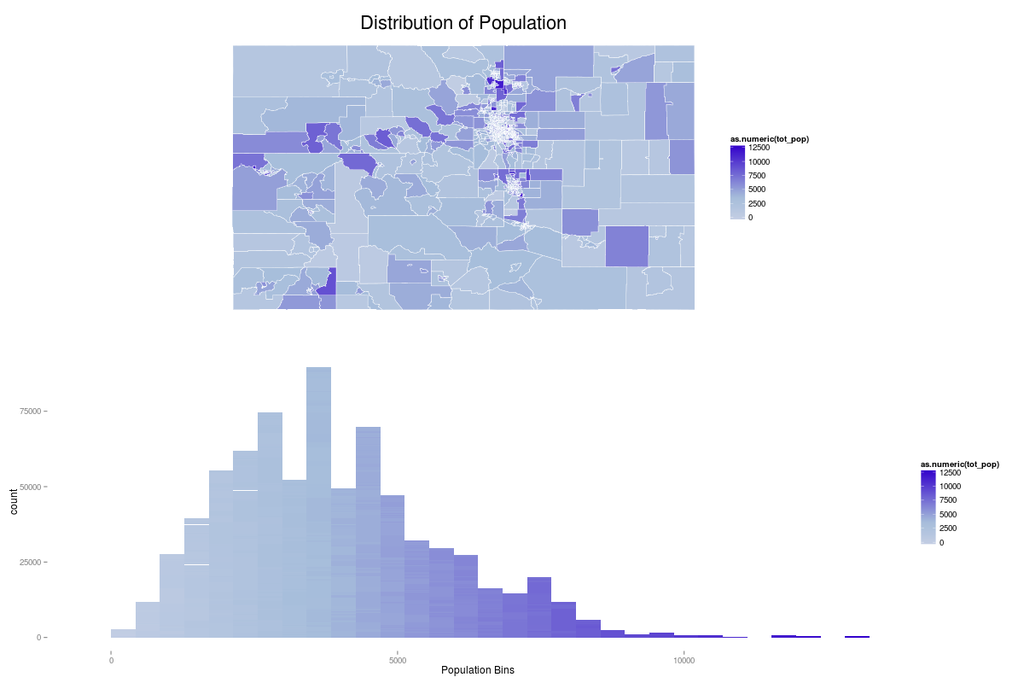

```python
%%R -w 1200 -h 800
library(gridExtra)
library(RColorBrewer)

#Set theme for histograms
theme_hist <- list(theme(panel.grid.minor = element_blank(),
                        panel.grid.major = element_blank(),
                        panel.background = element_blank(),
                        plot.background = element_blank(),
                        panel.border = element_blank(),
                        plot.title = element_text(size=22)))

#Plot map
pop_dist<-ggplot(aes(x=long,y=lat,group=group,fill=as.numeric(tot_pop)),data=co_mapd) +
            geom_polygon(colour='white',size=.2) +
            coord_equal() +
            theme_opts +
            labs(title='Distribution of Population') +
            scale_fill_gradient2(low='#ECE7F2',mid='#A6BDDB',high='#3300CC',
                                 midpoint=median(as.numeric(co_mapd$tot_pop)))
#ggsave('co_tract_pop_2010_map.png')

#Plot histogram
pop_hist<-ggplot(aes(x=as.numeric(tot_pop),group=group,fill=as.numeric(tot_pop)),data=co_mapd) +
            geom_histogram() +
            theme_hist +
            xlab('Population Bins') +
            scale_fill_gradient2(low='#ECE7F2',mid='#A6BDDB',high='#3300CC',
                                 midpoint=median(as.numeric(co_mapd$tot_pop)))
#ggsave('co_tract_pop_2010_hist.png')

#Throw plots on a single canvas
grid.arrange(pop_dist,pop_hist)
```

As expected, much of the state is sparsely populated, there are really only a few densely inhabited areas.

To the extent that homeownership impacts the political will for property taxation, it would be interesting to map the ratio of owner-occupied to rental housing.

```
stat_bin: binwidth defaulted to range/30. Use 'binwidth = x' to adjust this.
```

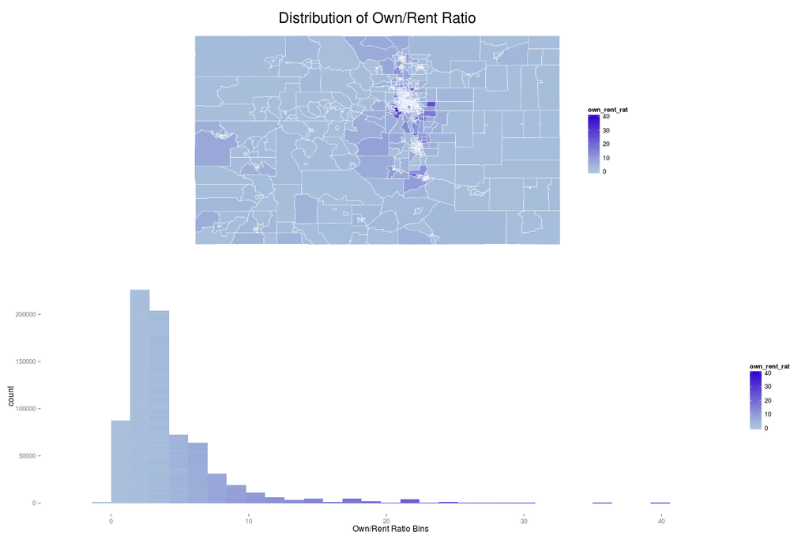

```python
%%R -w 1200 -h 800

#Calculate ratio of owner-occupied to rental housing
co_mapd$own_rent_rat<-as.numeric(co_mapd$own_occ)/as.numeric(co_mapd$gen_rent_occ)

#Replace NAs created by zero division
co_mapd[is.na(co_mapd)]<--1

#Plot
or_rat_dist<-ggplot(aes(x=long,y=lat,group=group,fill=own_rent_rat),data=co_mapd) + geom_polygon(colour='white',size=.2) +
    coord_equal() + theme_opts + labs(title='Distribution of Own/Rent Ratio') +
    scale_fill_gradient2(low='#ECE7F2',mid='#A6BDDB',high='#3300CC',
                         midpoint=median(co_mapd$own_rent_rat))

or_rat_hist<-ggplot(aes(x=own_rent_rat,group=group,fill=own_rent_rat),data=co_mapd)+geom_histogram() + theme_hist +
    xlab('Own/Rent Ratio Bins') +
    scale_fill_gradient2(low='#ECE7F2',mid='#A6BDDB',high='#3300CC',
                         midpoint=median(co_mapd$own_rent_rat))

grid.arrange(or_rat_dist,or_rat_hist)
```

It would be useful to roll through all of the variables in quick and dirty fashion to proivde an idea of any need for deeper focus.

*as.numeric()* seems to cause problems inside of a function, so let's try converting all columns to numeric before executing the function.

```python
%%R
#Convert to numeric
co_mapd[,21:42] <- sapply(co_mapd[,21:42], as.numeric)

#Confirm conversion
print(str(co_mapd))
```

```
'data.frame':	748351 obs. of  48 variables:
 $ id          : chr  "0" "0" "0" "0" ...
 $ long        : num  -107 -107 -107 -107 -107 ...
 $ lat         : num  37.4 37.4 37.5 37.5 37.5 ...
 $ order       : int  1 2 3 4 5 6 7 8 9 10 ...
 $ hole        : logi  FALSE FALSE FALSE FALSE FALSE FALSE ...
 $ piece       : Factor w/ 4 levels "1","2","3","4": 1 1 1 1 1 1 1 1 1 1 ...
 $ group       : Factor w/ 1280 levels "0.1","1.1","2.1",..: 1 1 1 1 1 1 1 1 1 1 ...
 $ GEOID       : Factor w/ 1249 levels "08001007801",..: 754 754 754 754 754 754 754 754 754 754 ...
 $ STATEFP     : Factor w/ 1 level "08": 1 1 1 1 1 1 1 1 1 1 ...
 $ COUNTYFP    : Factor w/ 64 levels "001","003","005",..: 28 28 28 28 28 28 28 28 28 28 ...
 $ TRACTCE     : Factor w/ 1020 levels "000100","000101",..: 992 992 992 992 992 992 992 992 992 992 ...
 $ NAME.x      : Factor w/ 1020 levels "1","10","100",..: 958 958 958 958 958 958 958 958 958 958 ...
 $ NAMELSAD    : Factor w/ 1020 levels "Census Tract 1",..: 958 958 958 958 958 958 958 958 958 958 ...
 $ MTFCC       : Factor w/ 1 level "G5020": 1 1 1 1 1 1 1 1 1 1 ...
```

[output cut: 35 more lines]

```
stat_bin: binwidth defaulted to range/30. Use 'binwidth = x' to adjust this.
```

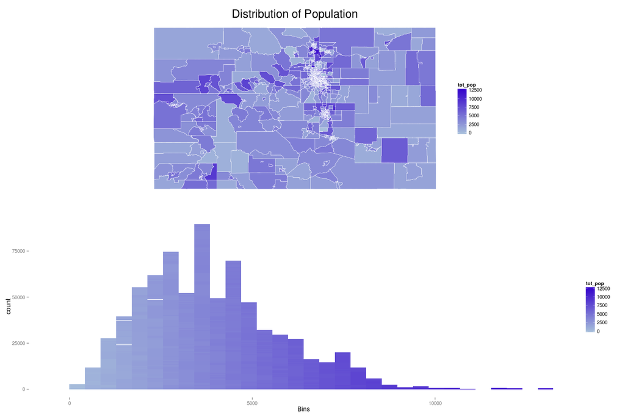

```python
%%R -w 1200 -h 800

map_var<-function(data,var,ttl,coord_x,coord_y,group='group'){
    dist<-ggplot(aes_string(x=coord_x,y=coord_y,group=group,fill=var),data=data) +
            geom_polygon(colour='white',size=.2) +
            coord_equal() +
            theme_opts +
            labs(title=ttl) +
            scale_fill_gradient2(low='#ECE7F2',mid='#A6BDDB',high='#3300CC')

    hist<-ggplot(aes_string(x=var,group=group,fill=var),data=data) +
            geom_histogram() +
            theme_hist +
            xlab('Bins') +
            scale_fill_gradient2(low='#ECE7F2',mid='#A6BDDB',high='#3300CC')

    grid.arrange(dist,hist)
    }

map_var(co_mapd,var='tot_pop',ttl='Distribution of Population',coord_x='long',coord_y='lat')
```

The function works! Now we just need to generate a vector of variables of interest and run through each, creating similar plots.

[output not shown]

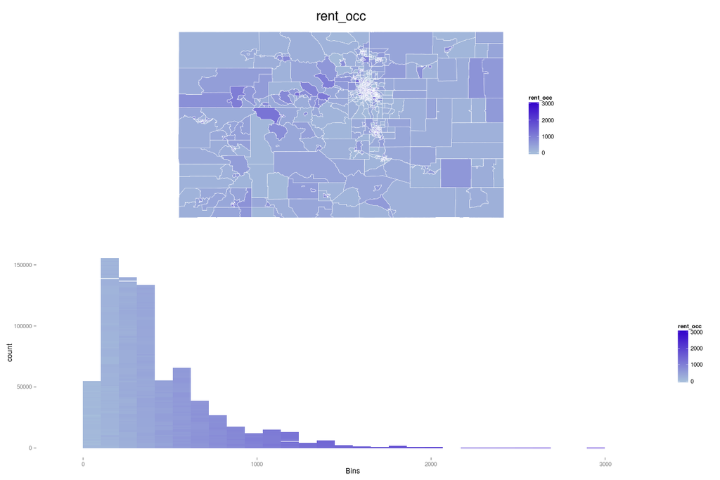

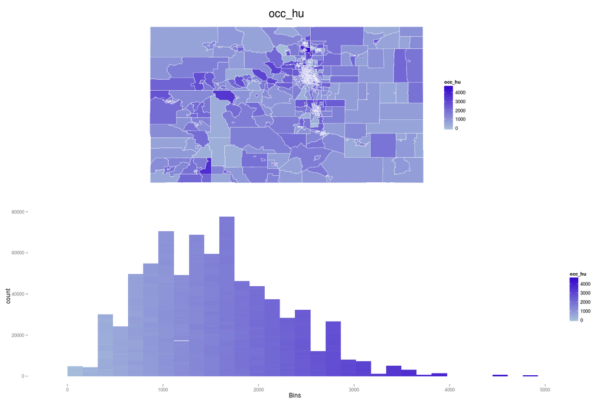

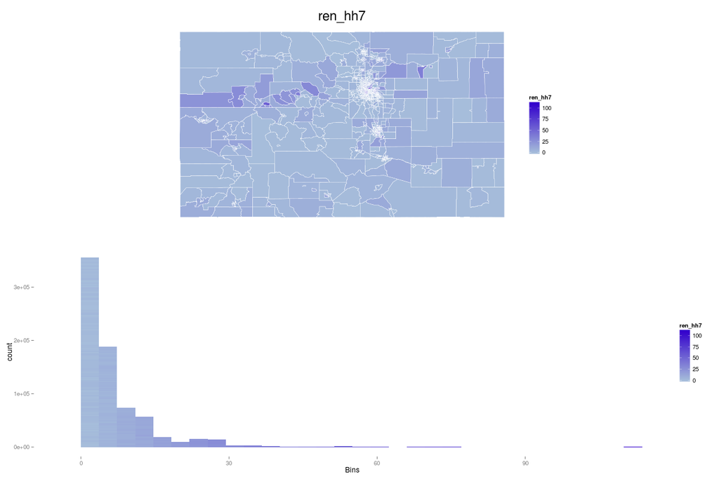

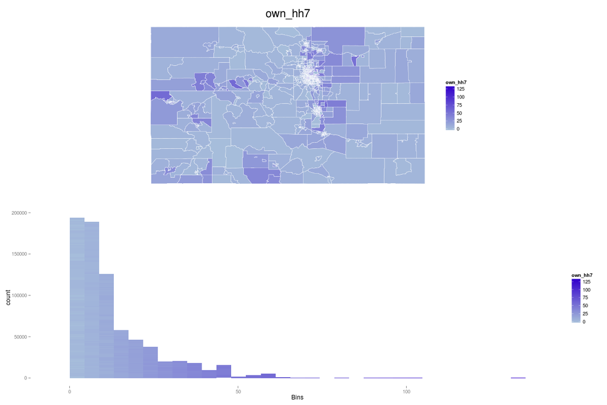

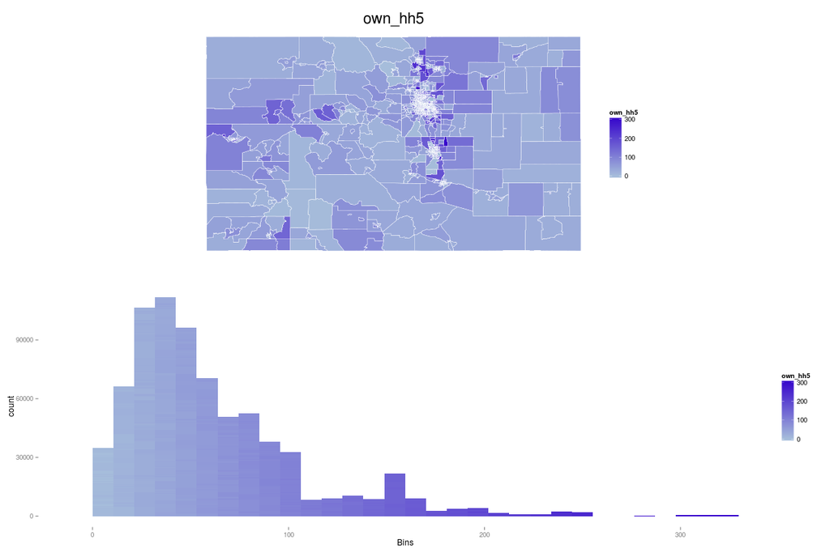

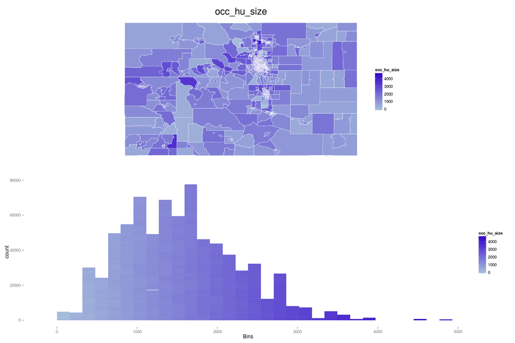

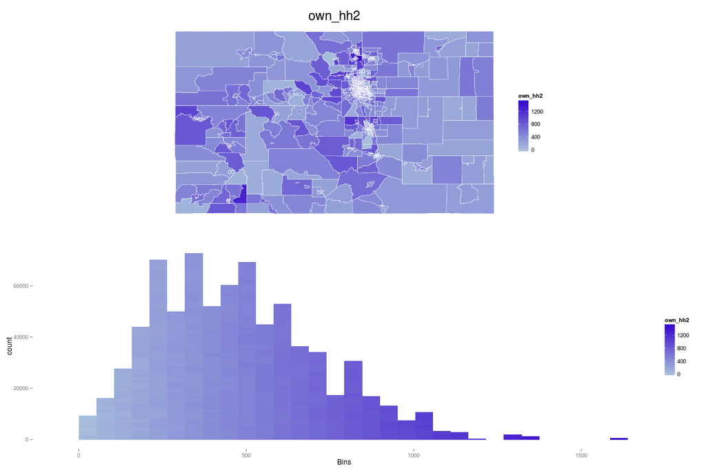

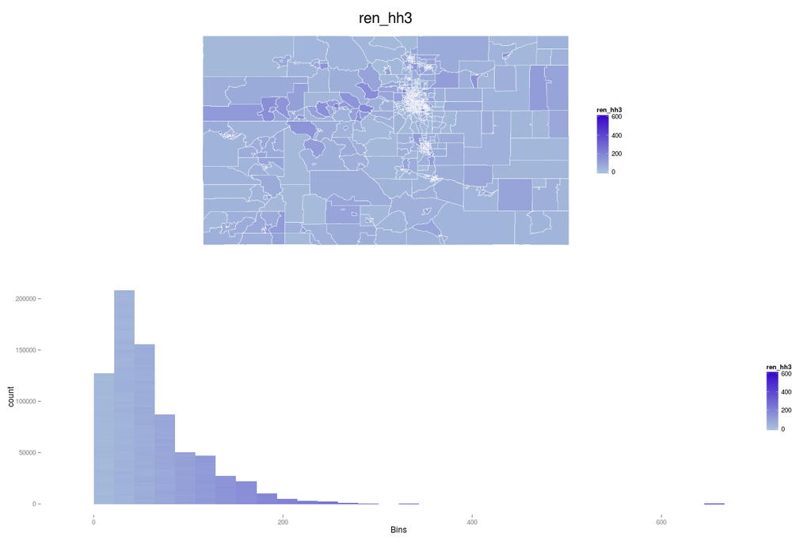

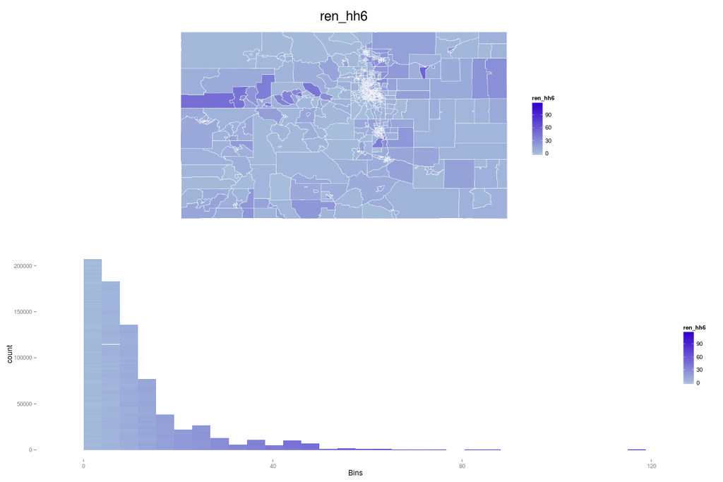

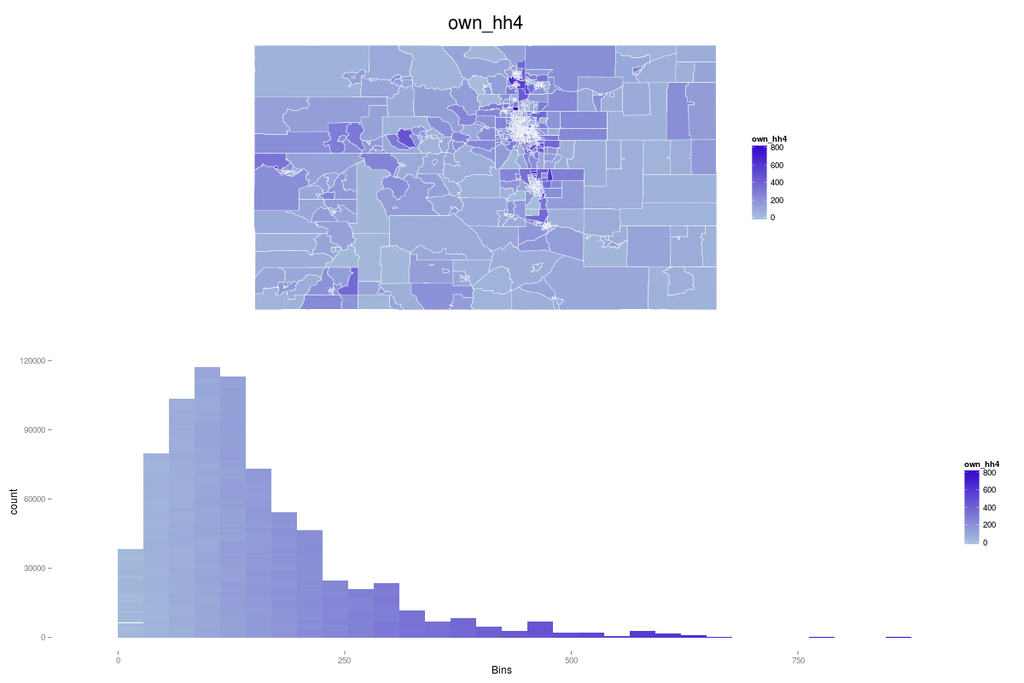

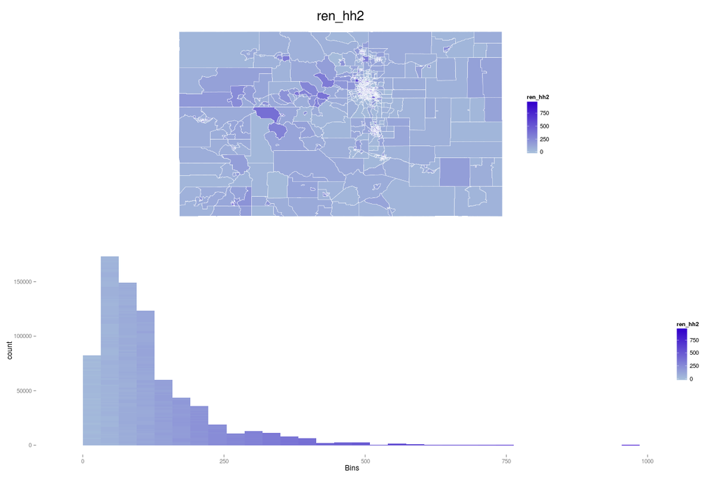

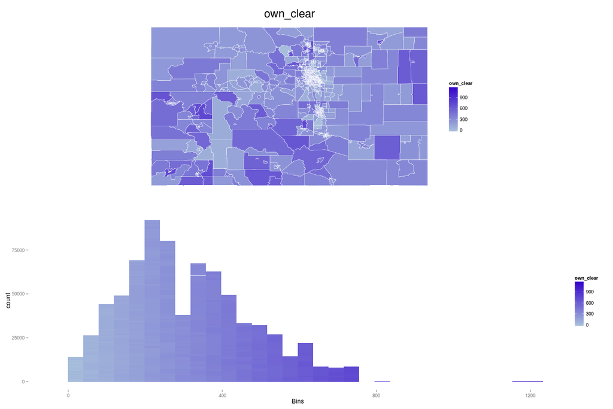

[10 more figures not shown]

```python
%%R -w 1200 -h 800

cens_var<-colnames(co_mapd)[21:42]

sapply(cens_var,function(x) map_var(co_mapd,var=x,ttl=x,coord_x='long',coord_y='lat'))
```